# FinalProject

Achilles Isidore Israel

2025-05-19

Read the dataset of Pixar Films

```r
pixar_films <- readr::read_csv('https://raw.githubusercontent.com/rfordatascience/tidytuesday/main/data/2025/2025-03-11/pixar_films.csv')
public_response <- readr::read_csv('https://raw.githubusercontent.com/rfordatascience/tidytuesday/main/data/2025/2025-03-11/public_response.csv')
box_office <- readr::read_csv('https://raw.githubusercontent.com/erictleung/pixarfilms/master/data-raw/box_office.csv')
```

##Run an exploratory data analysis (EDA) to investigate the dataset.

```r
##Load necessary packages
library(tidyverse)
library(tidytuesdayR)

##View structure of datasets
view(pixar_films)
view(public_response)
view(box_office)
```

Fixing Coding Error

```r
##Remove column 27 in the Pixar_films dataset
pixar_films <- pixar_films[-27, ]

##Replace missing values in running time with 0 (not the mean)
pixar_films$run_time[is.na(pixar_films$run_time)] <- 0

##Replace missing values in Rotten Tomatoes with 0 (not the mean)
public_response$rotten_tomatoes[is.na(public_response$rotten_tomatoes)] <- 0

##Replace missing values in Metacritic with 0 (not the mean)
public_response$metacritic[is.na(public_response$metacritic)] <- 0

##Replace missing values in critics_choice with 0 (not the mean)
public_response$critics_choice[is.na(public_response$critics_choice)] <- 0

##Replace missing values in cinema_score with N/A
public_response$cinema_score[is.na(public_response$cinema_score)] <- "N/A"

##Ensure dates and numeric values are correctly typed
pixar_films$release_date <- as.Date(pixar_films$release_date)

pixar_films$run_time <- as.integer(pixar_films$run_time)

public_response$rotten_tomatoes <- as.integer(public_response$rotten_tomatoes)

public_response$metacritic <- as.integer(public_response$metacritic)

public_response$critics_choice <- as.integer(public_response$critics_choice)

##Match Film Names across datasets (Trim and Clean)
pixar_films$film <- trimws(pixar_films$film)
public_response$film <- trimws(public_response$film)

pixar_films$film <- tolower(pixar_films$film)
public_response$film <- tolower(public_response$film)

box_office_trimmed <- box_office %>%
  select(film, box_office_worldwide)

box_office_trimmed$film <- tolower(box_office_trimmed$film)
```

Make one data set adding pixar_films, public_responses, and box_office_worldwide of the box_office data set

```r
library(dplyr)

##Ensure Film columns are clean and aligned
pixar_films <- pixar_films %>%
  mutate(film = str_trim(film))

public_response <- public_response %>%
  mutate(film = str_trim(film))

##Join the three datasets
combined_data <- pixar_films %>%
  right_join(public_response, by = "film") %>%
  left_join(box_office_trimmed, by = "film")
```

Add column to find the average of rotten tomatoes, metacritic, and critic’s choice

```r
##Install and Load package/s
library(purrr)
library(dplyr)

##Find the average score
combined_data <- combined_data %>%
  mutate(
    average_public_response_score = pmap_dbl(
      list(rotten_tomatoes, metacritic, critics_choice),
      function(rt, mc, cc) {
        scores <- c(rt, mc, cc)
        valid_scores <- scores[scores > 0 & !is.na(scores)]
        if (length(valid_scores) == 0) NA else mean(valid_scores)}))

##Top 10
top_10 <- combined_data %>%
  arrange(desc(average_public_response_score)) %>%
  slice_head(n = 10)
```

Use ggplot for visualization for the Film and Public Response Scores (RT, MC, CC), and the Average Public Response Score but only showing the Top 10

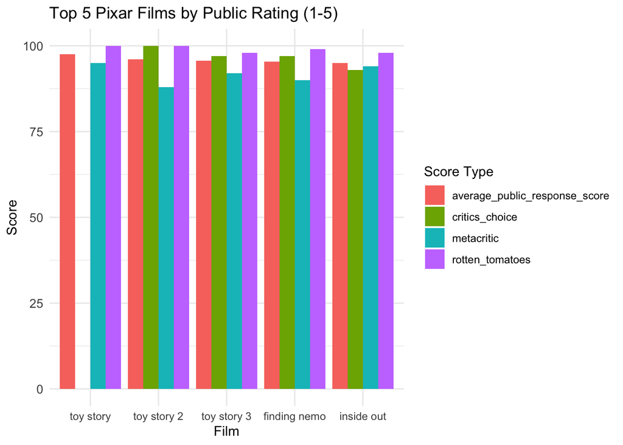

```r
##Load Packages
library(ggplot2)
library(tidyr)
library(dplyr)

##Get the top 10 films by average_score
top_10_films <- combined_data %>%
  arrange(desc(average_public_response_score)) %>%
  slice_head(n = 10) %>%
  pull(film)

##Filter combined_data to only top 10 films and arrange by descending average_score
filtered_data <- combined_data %>%
  filter(film %in% top_10_films) %>%
  arrange(desc(average_public_response_score)) %>%
  mutate(film = factor(film, levels = unique(film)))

##Split into two groups
films_first_5 <- levels(filtered_data$film)[1:5]
films_second_5 <- levels(filtered_data$film)[6:10]

##Prepare data for first 5 films
first_graph <- filtered_data %>%
  filter(film %in% films_first_5) %>%
  select(film, rotten_tomatoes, metacritic, critics_choice, average_public_response_score) %>%
  pivot_longer(
    cols = c(rotten_tomatoes, metacritic, critics_choice, average_public_response_score),
    names_to = "score_type",
    values_to = "score"
  ) %>%
  mutate(film = factor(film, levels = films_first_5))

##Prepare data for second 5 films
second_graph <- filtered_data %>%
  filter(film %in% films_second_5) %>%
  select(film, rotten_tomatoes, metacritic, critics_choice, average_public_response_score) %>%
  pivot_longer(
    cols = c(rotten_tomatoes, metacritic, critics_choice, average_public_response_score),
    names_to = "score_type",
    values_to = "score"
  ) %>%
  mutate(film = factor(film, levels = films_second_5))

##Plot the first 5 films
p1 <- ggplot(first_graph, aes(x = score, y = film, fill = score_type)) +
  geom_col(position = "dodge") +
  coord_flip() +
  labs(
    title = "Top 5 Pixar Films by Public Rating (1-5)",
    x = "Score",
    y = "Film",
    fill = "Score Type"
  ) +
  theme_minimal() +
  theme(axis.text.y = element_text(size = 10))

##Plot the next 5 films
p2 <- ggplot(second_graph, aes(x = score, y = film, fill = score_type)) +
  geom_col(position = "dodge") +
  coord_flip() +
  labs(
    title = "Top 5 Pixar Films by Public Rating (6-10)",
    x = "Score",
    y = "Film",
    fill = "Score Type"
  ) +
  theme_minimal() +
  theme(axis.text.y = element_text(size = 10))

print(p1)
```

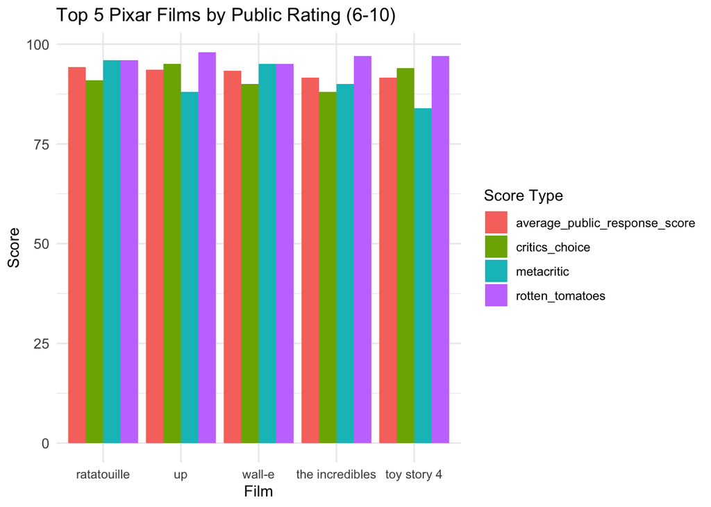

```r
print(p2)
```

Find the relationship between RT, MC, CC and box office performance.

Null Hypothesis: There is no relationship between RT, MC, CC, scores and worldwide box office revenue. Alternative Hypothesis: Higher RT, MC, CC, scores are associated with higher worldwide box office revenue.

```r
##
library(zoo)
##Find the relationship
model <- lm(box_office_worldwide ~ rotten_tomatoes + metacritic + critics_choice, data = combined_data)
summary(model)
```

```
##
## Call:
## lm(formula = box_office_worldwide ~ rotten_tomatoes + metacritic +
##     critics_choice, data = combined_data)
##
## Residuals:
##        Min         1Q     Median         3Q        Max
## -570780431 -152703762  -19627510  130924735  589222188
##
## Coefficients:
##                  Estimate Std. Error t value Pr(>|t|)
## (Intercept)     -24659726  231540912  -0.107    0.916
## rotten_tomatoes  -1252608    6870590  -0.182    0.857
## metacritic        6216148    7748239   0.802    0.432
## critics_choice    3458646    2176448   1.589    0.128
##
## Residual standard error: 277400000 on 20 degrees of freedom
## Multiple R-squared:  0.3202, Adjusted R-squared:  0.2183
## F-statistic: 3.141 on 3 and 20 DF,  p-value: 0.04806
```

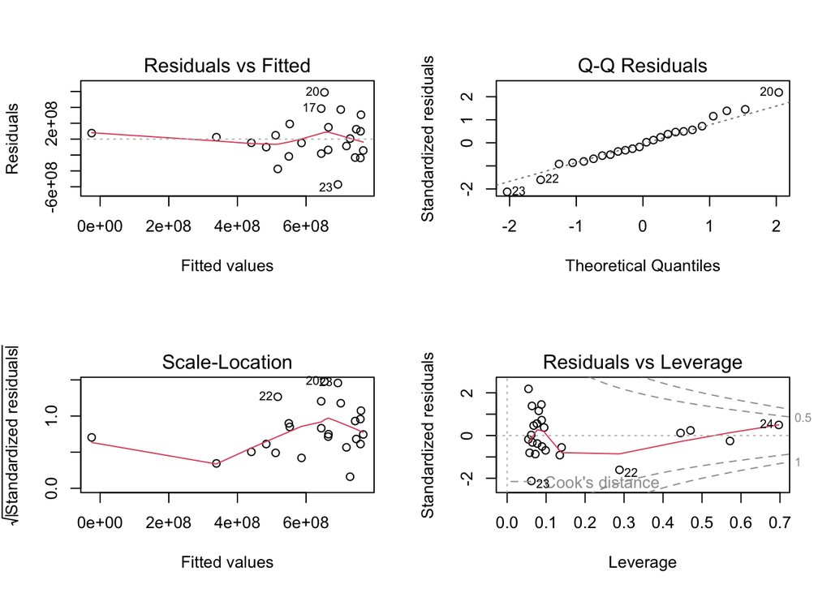

```r
#Check Residual Diagnostic
par(mfrow = c(2, 2))
plot(model)
```

```r
##Check Multicollinearity (Variance Inflation Factor)
library(car)
vif(model)
```

```
## rotten_tomatoes      metacritic  critics_choice
##        7.380078        7.388020        1.336126
```

```r
##Check Shapiro-Wilk Test for Normality of Residuals
shapiro.test(residuals(model))
```

```
##
##  Shapiro-Wilk normality test
##
## data:  residuals(model)
## W = 0.98655, p-value = 0.9806
```

```r
##Check Breusch-Pagan Test for Heteroscedasticity
library(lmtest)
bptest(model)
```

```
##
##  studentized Breusch-Pagan test
##
## data:  model
## BP = 4.2521, df = 3, p-value = 0.2355
```

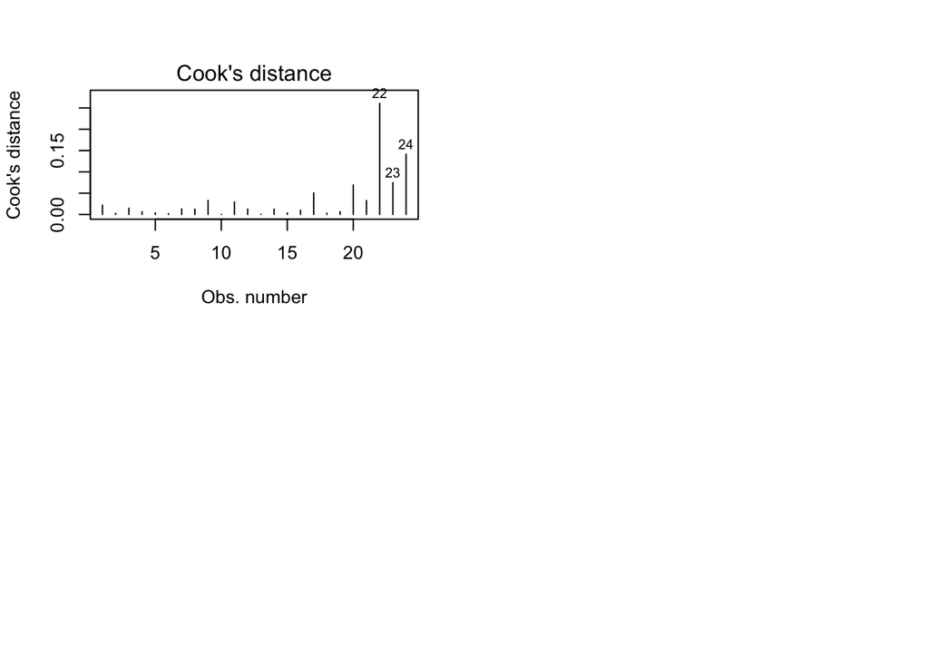

```r
##Check for Influential Observations (Cook's Distance)
plot(model, which = 4)
```

Test another hypothesis to check if there a difference in box office worldwide revenue between PG and G films?”

Null Hypothesis: There is no difference in mean worldwide box office revenue between PG and G films. Alternative Hypothesis: There is a difference in mean worldwide box office revenue between PG and G films.

```r
library(dplyr)

pg_g_data <- combined_data %>%
  filter(film_rating %in% c("G", "PG"), !is.na(box_office_worldwide))

t.test(box_office_worldwide ~ film_rating, data = pg_g_data)
```

```
##
##  Welch Two Sample t-test
##
## data:  box_office_worldwide by film_rating
## t = -0.15707, df = 14.828, p-value = 0.8773
## alternative hypothesis: true difference in means between group G and group PG is not equal to 0
## 95 percent confidence interval:
##  -308722636  266384799
## sample estimates:
##  mean in group G mean in group PG
##        623351538        644520457
```